# Analysis San Francisco Criminal Records (CMSC320 Final Project)

### Xuewen Zhou, Daoming Zhang

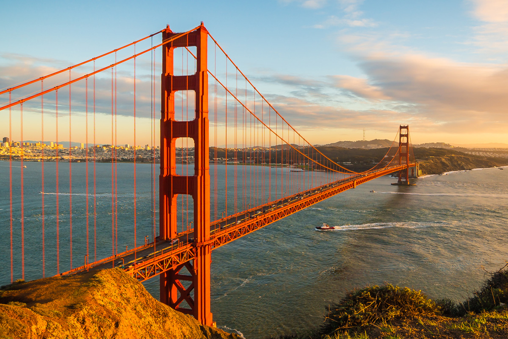

### Motivation

With a crime rate of 64 per one thousand residents, San Francisco has one of the highest crime rates in America compared to all communities of all sizes - from the smallest towns to the very largest cities. One's chance of becoming a victim of either violent or property crime here is one in 16. Within California, more than 99% of the communities have a lower crime rate than San Francisco.  
Separately, it is always interesting and important to compare a city's crime rate with those of similarly sized communities - a fair comparison as larger cities tend to have more crime. Neighborhood Scout has done just that. With a population of 883,305, San Francisco has a combined rate of violent and property crime that is very high compared to other places of similar population size. Regardless of whether San Francisco does well or poorly compare to all other cities and towns in the US of all sizes, compared to places with a similar population, it fares badly. Few other communities of this size have a crime rate as high as San Francisco. (https://www.neighborhoodscout.com/)

Monitoring and tracking crime records of cities seem relatively important. It implicitly states how crimes are committed and give the authorities a better way to analyze the features of crimes across cities and enforce more securities to reduce crimes efficiently.  
The primary purpose of crime analysis is to support or assist the operations of a police department. These functions include criminal investigation, apprehension, prosecution; patrol activities; crime prevention and reduction strategies; problem-solving; and police efforts' evaluation and accountability.  
In the San Francisco Crime Dashboard, https://www.sanfranciscopolice.org/stay-safe/crime-data/crime-dashboard, we can see the criminal analysis of recent years in San Francisco. We wanted to do a similar analysis on San Francisco in 2016.  
Therefore, we share this tutorial on analyzing a San Fransico Crime DataSet in data science that we learned throughout the class, CMSC320.  
This project's overall objective will be to analyze the crime data of San Francisco in 2016 and hope to inform the general public of the San Francisco community about what we conclude about the dataset.

### Table of Contents:

- Data Scraping & Cleaning
- Analysis on Single Attribute
- Analysis on Multiple Attributes
- Exploratory Data Analysis Using Interactive Map
- Conclusion

## Data Scraping & Cleaning

First, we need to load the libraries needed for this project.

```python
import pandas as pd
import numpy as np
import re
import matplotlib.pyplot as plt
from matplotlib import rcParams
import seaborn as sns
import folium
import random
import pylab
```

To start, we load the dataset from (https://www.kaggle.com/roshansharma/sanfranciso-crime-dataset) on the Kaggle provided by Roshan Sharma to give a tutorial on how to do the anaylsis.

```python
records = pd.read_csv("Police_Department_Incidents_-_Previous_Year__2016_.csv")
records.head()
```

|  | IncidntNum | Category | Descript | DayOfWeek | Date | Time | PdDistrict | Resolution | Address | X | Y | Location | PdId |
| --- | --- | --- | --- | --- | --- | --- | --- | --- | --- | --- | --- | --- | --- |
| 0 | 120058272 | WEAPON LAWS | POSS OF PROHIBITED WEAPON | Friday | 01/29/2016 12:00:00 AM | 11:00 | SOUTHERN | ARREST, BOOKED | 800 Block of BRYANT ST | -122.403405 | 37.775421 | (37.775420706711, -122.403404791479) | 12005827212120 |
| 1 | 120058272 | WEAPON LAWS | FIREARM, LOADED, IN VEHICLE, POSSESSION OR USE | Friday | 01/29/2016 12:00:00 AM | 11:00 | SOUTHERN | ARREST, BOOKED | 800 Block of BRYANT ST | -122.403405 | 37.775421 | (37.775420706711, -122.403404791479) | 12005827212168 |
| 2 | 141059263 | WARRANTS | WARRANT ARREST | Monday | 04/25/2016 12:00:00 AM | 14:59 | BAYVIEW | ARREST, BOOKED | KEITH ST / SHAFTER AV | -122.388856 | 37.729981 | (37.7299809672996, -122.388856204292) | 14105926363010 |
| 3 | 160013662 | NON-CRIMINAL | LOST PROPERTY | Tuesday | 01/05/2016 12:00:00 AM | 23:50 | TENDERLOIN | NONE | JONES ST / OFARRELL ST | -122.412971 | 37.785788 | (37.7857883766888, -122.412970537591) | 16001366271000 |
| 4 | 160002740 | NON-CRIMINAL | LOST PROPERTY | Friday | 01/01/2016 12:00:00 AM | 00:30 | MISSION | NONE | 16TH ST / MISSION ST | -122.419672 | 37.765050 | (37.7650501214668, -122.419671780296) | 16000274071000 |

Check if there are null values in the dataset. Originally, we have 150500 of criminal cases in the dataset. We can see that there is one null value in the pdDistrict, we remove the entry from the dataset. So now there are 150499 criminal cases in the dataset.

```python
# remove NULL
print(records.shape)
print(records.isnull().sum())
records = records.dropna()
print(records.shape)
```

```
(150500, 13)
IncidntNum    0
Category      0
Descript      0
DayOfWeek     0
Date          0
Time          0
PdDistrict    1
Resolution    0
Address       0
X             0
Y             0
Location      0
PdId          0
dtype: int64
(150499, 13)
```

Now, we'll tidy the data a little bit. We notice that there are attributes Date and Time in the data frame and the Date field, all the time is 12 am. So we will drop the time in the Date field and combine it with the Time attribute. Then, turn it from str to DateTime.

```python
records["Date"] = records["Date"].str.split(" ").str[0]
records["DateTime"] = records["Date"] + " " + records["Time"]
records["DateTime"] = pd.to_datetime(records["DateTime"])
```

Remove unnecessary attributes in the dataset. Incident number and Pd id, we do not need this for analysis the data; Location, we already have longitude and latitude so we can remove Location field; Date and Time, in last step we already combine Date field and Time field into DateTime field so we can remove Date and Time fields. Then, we rename the field X and Y into long and lat and turn them into float type for future use.

```python
# remove useless data
records = records.drop(columns=["IncidntNum", "Location", "PdId", "Date", "Time"])
# rename column name
records = records.rename(columns={"X": "long", "Y": "lat"})
records["long"] = records["long"].astype(float)
records["lat"] = records["lat"].astype(float)
records.head()
```

|  | Category | Descript | DayOfWeek | PdDistrict | Resolution | Address | long | lat | DateTime |
| --- | --- | --- | --- | --- | --- | --- | --- | --- | --- |
| 0 | WEAPON LAWS | POSS OF PROHIBITED WEAPON | Friday | SOUTHERN | ARREST, BOOKED | 800 Block of BRYANT ST | -122.403405 | 37.775421 | 2016-01-29 11:00:00 |
| 1 | WEAPON LAWS | FIREARM, LOADED, IN VEHICLE, POSSESSION OR USE | Friday | SOUTHERN | ARREST, BOOKED | 800 Block of BRYANT ST | -122.403405 | 37.775421 | 2016-01-29 11:00:00 |
| 2 | WARRANTS | WARRANT ARREST | Monday | BAYVIEW | ARREST, BOOKED | KEITH ST / SHAFTER AV | -122.388856 | 37.729981 | 2016-04-25 14:59:00 |
| 3 | NON-CRIMINAL | LOST PROPERTY | Tuesday | TENDERLOIN | NONE | JONES ST / OFARRELL ST | -122.412971 | 37.785788 | 2016-01-05 23:50:00 |
| 4 | NON-CRIMINAL | LOST PROPERTY | Friday | MISSION | NONE | 16TH ST / MISSION ST | -122.419672 | 37.765050 | 2016-01-01 00:30:00 |

## Analysis on Single Attribute

This section will analyze a single attribute to see if we can make an initial conclusion on the dataset to create a more in-depth analysis in later sections.  
First, we want to see if there is a relationship between the crime rate and the month in a year using a pie chart.

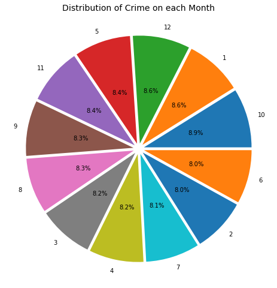

```python
data = records['DateTime'].dt.month.value_counts()
pie, ax = plt.subplots(figsize=[11.7,8.27])
labels = data.keys()
plt.pie(x=data, autopct="%.1f%%", explode=[0.05]*12, labels=labels, pctdistance=0.5)
plt.title("Distribution of Crime on each Month", fontsize=14);
```

From the graph above, we could see not much differences among each month. The distribution of crime rate in each month is almost equally distributed.  
Then, we want to see if there is a relationship between the crime rate and the day in a week using a pie chart.

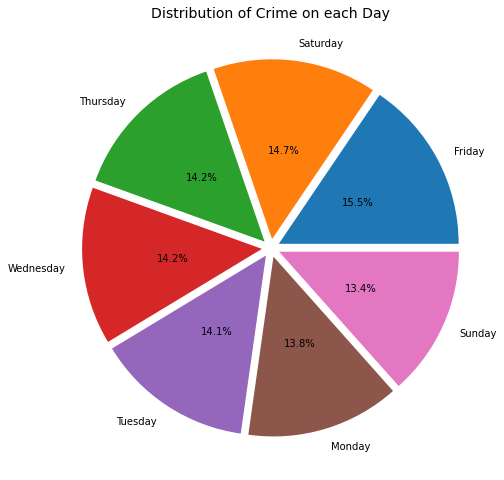

```python
data = records['DayOfWeek'].value_counts()
pie, ax = plt.subplots(figsize=[11.7,8.27])
labels = data.keys()
plt.pie(x=data, autopct="%.1f%%", explode=[0.05]*7, labels=labels, pctdistance=0.5)
plt.title("Distribution of Crime on each Day", fontsize=14);
```

From the graph above, we still could not see much difference among each day, but Friday seems to have a higher crime rate than other days. Therefore, we could suggest that authorities should enforce more security and shifts, especially on Friday.  
We want to see if there is a relationship between the crime rate and the time in a day using a different chart, a bar chart.

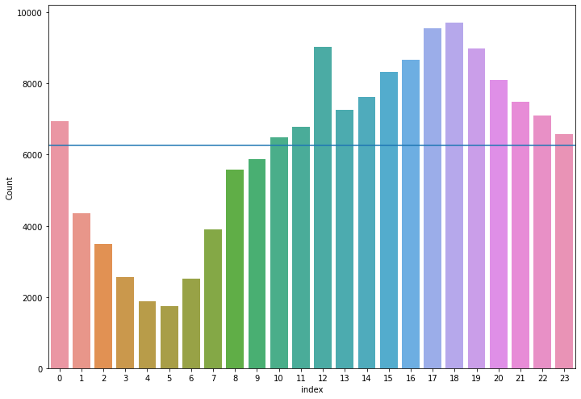

```python
data = records['DateTime'].dt.hour.value_counts()
table = pd.DataFrame(data=data.values, index=data.index, columns=['Count'])
table = table.reset_index()
rcParams['figure.figsize'] = 11.7,8.27
# graph = sns.lmplot(x='index', y='Count', data=table)
graph = sns.barplot(x='index', y='Count', data=table)
graph.axhline(table["Count"].mean())
plt.show()
# sns.countplot(records["DateTime"].dt.hour, palette = 'gnuplot')
```

In the bar chart, we could see that the least crimes were committed in the period of 05:00 - 05:59, and most crimes were committed in 18:00 - 18:59. Based on the boxplot, we could see that the period of 1:00 - 9:59 AM is when the crime is committed under the average value (the horizontal line). Therefore, the Police officer can have more security checks and shifts around the city after 12.  
Next, we want to see the majority category of criminal cases in San Francisco using a pie chart.

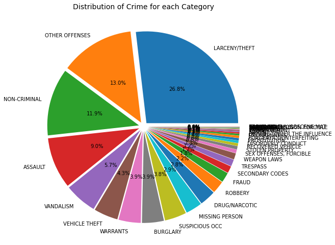

```python
data = records['Category'].value_counts()
pie, ax = plt.subplots(figsize=[11.7,8.27])
labels = data.keys()
plt.pie(x=data, autopct="%.1f%%", explode=[0.05]*len(data), labels=labels, pctdistance=0.5)
plt.title("Distribution of Crime for each Category", fontsize=14);
```

The chart above showed that the majorities category of criminal in San Francisco are LARCENY/THEFT, OTHER OFFENSES, and NON-CRIMINAL, especially larceny/theft, is more than a quarter of the chart. Therefore, we could suggest authorities should take action and prevention to crimes of robbery and theft more.  
Last, we want to see the distribution of criminal cases for each district in San Francisco using a pie chart.

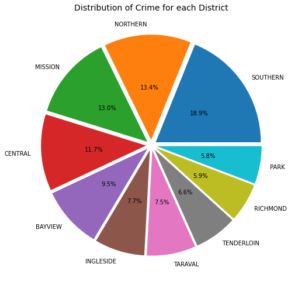

```python
data = records['PdDistrict'].value_counts()
pie, ax = plt.subplots(figsize=[11.7,8.27])
labels = data.keys()
plt.pie(x=data, autopct="%.1f%%", explode=[0.05]*len(data), labels=labels, pctdistance=0.5)
plt.title("Distribution of Crime for each District", fontsize=14);
```

## Analysis on Multiple Attributes

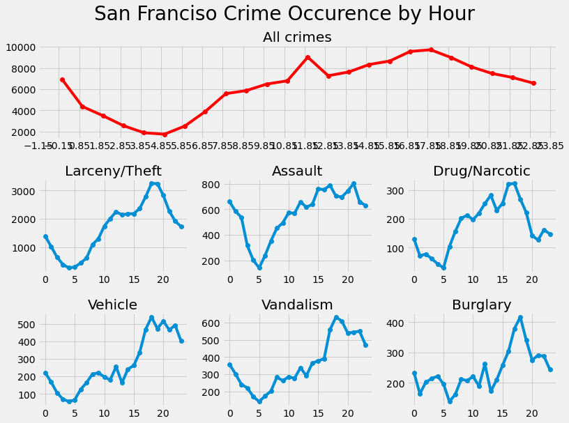

```python
pylab.rcParams['figure.figsize'] = (11.7,8.27)

records['Hour'] = records['DateTime'].dt.hour

larceny = records[records['Category'] == "LARCENY/THEFT"]
assault = records[records['Category'] == "ASSAULT"]
drug = records[records['Category'] == "DRUG/NARCOTIC"]
vehicle = records[records['Category'] == "VEHICLE THEFT"]
vandalism = records[records['Category'] == "VANDALISM"]
burglary = records[records['Category'] == "BURGLARY"]

with plt.style.context('fivethirtyeight'):
    ax1 = plt.subplot2grid((3,3), (0,0), colspan=3)
    ax1.plot(records.groupby('Hour').size(), 'ro-')
    ax1.set_title ('All crimes')
    start, end = ax1.get_xlim()
    ax1.xaxis.set_ticks(np.arange(start, end, 1))

    ax2 = plt.subplot2grid((3,3), (1, 0))
    ax2.plot(larceny.groupby('Hour').size(), 'o-')
    ax2.set_title ('Larceny/Theft')

    ax3 = plt.subplot2grid((3,3), (1, 1))
    ax3.plot(assault.groupby('Hour').size(), 'o-')
    ax3.set_title ('Assault')

    ax4 = plt.subplot2grid((3,3), (1, 2))
    ax4.plot(drug.groupby('Hour').size(), 'o-')
    ax4.set_title ('Drug/Narcotic')

    ax5 = plt.subplot2grid((3,3), (2, 0))
    ax5.plot(vehicle.groupby('Hour').size(), 'o-')
    ax5.set_title ('Vehicle')

    ax6 = plt.subplot2grid((3,3), (2, 1))
    ax6.plot(vandalism.groupby('Hour').size(), 'o-')
    ax6.set_title ('Vandalism')

    ax7 = plt.subplot2grid((3,3), (2, 2))
    ax7.plot(burglary.groupby('Hour').size(), 'o-')
    ax7.set_title ('Burglary')

    pylab.gcf().text(0.5, 1.03,
                    'San Franciso Crime Occurence by Hour',
                     horizontalalignment='center',
                     verticalalignment='top',
                     fontsize = 28)

plt.tight_layout(2)
plt.show()
```

According to the above charts, we can see the crime rate distribution in a day for each type of crime. For larceny/theft, the highest quality of crime time is around 6 pm in a day and other times in a day are significantly lower. For assault, the primary crime time is between 12 pm to 12 am. For drug/narcotic, the primary crime time is between 10 am to 7 pm. For vehicles, the primary crime time is 7 pm to 12 am. For vandalism and burglary, the highest rate of crime time is around 7 pm. To conclude, assault and drug/narcotic seem to distribute a longer time in a day.  
Next, we want to see if there is a relationship between Category and Month.

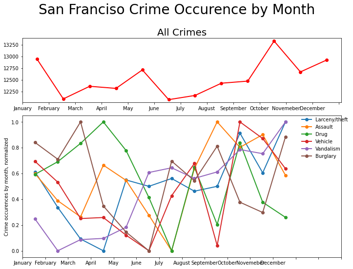

```python
records['Month'] = records['DateTime'].dt.month
monthsIdx = records.groupby('Month').size().keys() - 1
monthsLit = ['January', 'February',
             'March', 'April', 'May',
             'June', 'July','August',
             'September', 'October', 'Novemeber', 'December']
occursByMonth = records.groupby('Month').size()
larceny = records[records['Category'] == "LARCENY/THEFT"]
assault = records[records['Category'] == "ASSAULT"]
drug = records[records['Category'] == "DRUG/NARCOTIC"]
vehicle = records[records['Category'] == "VEHICLE THEFT"]
vandalism = records[records['Category'] == "VANDALISM"]
burglary = records[records['Category'] == "BURGLARY"]
# Linear plot for all crimes
ax1 = plt.subplot2grid((3,3), (0,0), colspan=3)
ax1.plot(monthsIdx, occursByMonth, 'ro-', linewidth=2)

ax1.set_title ('All Crimes', fontsize=20)

start, end = ax1.get_xlim()
ax1.xaxis.set_ticks(np.arange(start, end, 1))
ax1.set_xticklabels(monthsLit)
# ensure that ticks are only at the bottom and left parts of the plot
ax1.get_xaxis().tick_bottom()
ax1.get_yaxis().tick_left()

# Linear normalized plot for 6 top crimes
ax2 = plt.subplot2grid((3,3), (1,0), colspan=3, rowspan=2)

y = np.empty([6,12])
y[0] = larceny.groupby('Month').size()
y[1] = assault.groupby('Month').size()
y[2] = drug.groupby('Month').size()
y[3] = vehicle.groupby('Month').size()
y[4] = vandalism.groupby('Month').size()
y[5] = burglary.groupby('Month').size()

crimes = ['Larceny/theft', 'Assault', 'Drug', 'Vehicle', 'Vandalism', 'Burglary']
color_sequence = ['#1f77b4', '#ff7f0e', '#2ca02c','#d62728', '#9467bd', '#8c564b']

h = [None]*6

for i in range(0,6):
    y[i]= (y[i]-min(y[i]))/(max(y[i])-min(y[i]))  # normalization
    h[i] = ax2.plot(monthsIdx, y[i],'o-', color=color_sequence[i], lw=2)

ax2.set_ylabel("Crime occurences by month, normalized")

ax2.xaxis.set_ticks(np.arange(start, end+2, 1))
ax2.set_xticklabels(monthsLit)

ax2.legend((item[0] for item in h),
           crimes,
           bbox_to_anchor=(0.87, 1), loc=2, borderaxespad=0., frameon=False)

pylab.gcf().text(0.5, 1.00,
            'San Franciso Crime Occurence by Month',
            horizontalalignment='center',
            verticalalignment='top',
             fontsize = 28)
plt.show()
```

## Exploratory Data Analysis Using Interactive Map

In this section, we want to have a better understanding of whether there’s a certain area in San Francisco that has a higher criminal rate.

```python
table = pd.DataFrame(data=data.values, index=data.index, columns=['Count'])
table = table.reset_index()
table = table.rename(columns={"index": "District"})

gjson = r'https://cocl.us/sanfran_geojson'
map_osm = folium.Map(location=[37.7740, -122.4313], zoom_start=12)
folium.Choropleth(
    geo_data=gjson,
    data=table,
    columns=['District', 'Count'],
    key_on='feature.properties.DISTRICT',
    fill_color='YlOrRd',
    fill_opacity=0.7,
    line_opacity=0.2,
    legend_name='Crime Rate in San Francisco').add_to(map_osm)

map_osm
```

Make this Notebook Trusted to load map: File -> Trust Notebook

[interactive chart not shown]